# Paki_data

## ***Day-13***

## **Pakistan Population dataset**

The data was collected from the following [link](https://www.kaggle.com/datasets/mabdullahsajid/population-of-pakistan-dataset):

**Years of the data**

1. 2017
2. 1998

**Author Name:** Muhammad Adnan  
**Email:** adnanagri12@gmail.com

About Dataset  
`Description` This dataset contains demographic information from the Pakistan Population Census conducted in 2017. It provides detailed population data at various administrative levels within Pakistan, including provinces, divisions, districts, and sub-divisions. The dataset also includes information on urban and rural populations, gender distribution, transgender individuals, sex ratios, population figures from the 1998 census, and annual growth rates.

`Features` Province: The administrative provinces or regions of Pakistan where the census data was collected.

Division: The divisions within each province. Divisions are the second level of administrative divisions in Pakistan.

District: Districts within each division, representing larger administrative units.

Sub-Division: Sub-divisions or tehsils within each district, providing more localized data. Area: The land area (in square kilometers) of each sub-division.

Urban Population 2017: The population of urban areas within each sub-division for the year 2017.

Rural Population 2017: The population of rural areas within each sub-division for the year 2017.

Male Population 2017: The male population within each sub-division for the year 2017.

Female Population 2017: The female population within each sub-division for the year 2017.

Transgender Population 2017: The population of transgender individuals within each sub-division for the year 2017.

Population in 1998: The total population of each sub-division as recorded in the 1998 census.

Annual Growth Rate: The annual growth rate of the population in each sub-division, calculated as the percentage increase from 1998 to 2017.

`Data Source` The data in this dataset was collected from official Pakistan Population Census reports and may include data from various government sources. It is essential to provide proper attribution and reference the original sources when using this dataset for analysis or research.

`Data Usage` Researchers and analysts can use this dataset to explore demographic trends, population growth, urbanization rates, gender distribution, and more within Pakistan at different administrative levels. Ensure compliance with ethical and legal guidelines when using this data for research or public sharing.

Please note that this description is a template, and you should adapt it based on the actual data sources and specific details of your dataset when creating it for Kaggle or any other platform.

## Purpose of this analysis:

```python
# import libraries
import pandas as pd
import numpy as np
import seaborn as sns
import matplotlib.pyplot as plt
```

```python
# load dataset
df = pd.read_csv('../pandas_tips_tricks/Data/Pakistan-data.csv')
df.head()
```

|  | PROVINCE | DIVISION | DISTRICT | SUB DIVISION | AREA (sq.km) | ALL SEXES (RURAL) | MALE (RURAL) | FEMALE (RURAL) | TRANSGENDER (RURAL) | SEX RATIO (RURAL) | AVG HOUSEHOLD SIZE (RURAL) | POPULATION 1998 (RURAL) | ANNUAL GROWTH RATE (RURAL) | ALL SEXES (URBAN) | MALE (URBAN) | FEMALE (URBAN) | TRANSGENDER (URBAN) | SEX RATIO (URBAN) | AVG HOUSEHOLD SIZE (URBAN) | POPULATION 1998 (URBAN) | ANNUAL GROWTH RATE (URBAN) |
| --- | --- | --- | --- | --- | --- | --- | --- | --- | --- | --- | --- | --- | --- | --- | --- | --- | --- | --- | --- | --- | --- |
| 0 | PUNJAB | BAHAWALPUR DIVISION | BAHAWALNAGAR DISTRICT | BAHAWALNAGAR TEHSIL | 1729.0 | 619550 | 316864 | 302644 | 42 | 104.70 | 6.10 | 407768 | 2.22 | 193840 | 98391 | 95402 | 47 | 103.13 | 6.02 | 133785 | 1.97 |
| 1 | PUNJAB | BAHAWALPUR DIVISION | BAHAWALNAGAR DISTRICT | CHISHTIAN TEHSIL | 1500.0 | 540342 | 273788 | 266500 | 54 | 102.73 | 6.15 | 395983 | 1.65 | 149424 | 75546 | 73851 | 27 | 102.30 | 6.01 | 102287 | 2.01 |
| 2 | PUNJAB | BAHAWALPUR DIVISION | BAHAWALNAGAR DISTRICT | FORT ABBAS TEHSIL | 2536.0 | 361240 | 182655 | 178541 | 44 | 102.30 | 6.32 | 250959 | 1.93 | 61528 | 31360 | 30150 | 18 | 104.01 | 6.00 | 34637 | 3.06 |
| 3 | PUNJAB | BAHAWALPUR DIVISION | BAHAWALNAGAR DISTRICT | HAROONABAD TEHSIL | 1295.0 | 382115 | 192278 | 189808 | 29 | 101.30 | 6.15 | 297343 | 1.33 | 142600 | 71345 | 71236 | 19 | 100.15 | 6.02 | 84424 | 2.79 |
| 4 | PUNJAB | BAHAWALPUR DIVISION | BAHAWALNAGAR DISTRICT | MINCHINABAD TEHSIL | 1818.0 | 452723 | 231506 | 221178 | 39 | 104.67 | 6.29 | 316593 | 1.90 | 72294 | 36694 | 35590 | 10 | 103.10 | 6.34 | 37668 | 3.48 |

## ***1. Composition***

```python
df.info()
```

```
<class 'pandas.core.frame.DataFrame'>
RangeIndex: 528 entries, 0 to 527
Data columns (total 21 columns):
 #   Column                      Non-Null Count  Dtype
---  ------                      --------------  -----
 0   PROVINCE                    528 non-null    object
 1   DIVISION                    528 non-null    object
 2   DISTRICT                    528 non-null    object
 3   SUB DIVISION                528 non-null    object
 4   AREA (sq.km)                528 non-null    float64
 5   ALL SEXES (RURAL)           528 non-null    int64
 6   MALE (RURAL)                528 non-null    int64
 7   FEMALE (RURAL)              528 non-null    int64
 8   TRANSGENDER (RURAL)         528 non-null    int64
 9   SEX RATIO (RURAL)           528 non-null    float64
 10  AVG HOUSEHOLD SIZE (RURAL)  528 non-null    float64
 11  POPULATION 1998 (RURAL)     528 non-null    int64
 12  ANNUAL GROWTH RATE (RURAL)  528 non-null    float64
 13  ALL SEXES (URBAN)           528 non-null    int64
 14  MALE (URBAN)                528 non-null    int64
 15  FEMALE (URBAN)              528 non-null    int64
 16  TRANSGENDER (URBAN)         528 non-null    int64
 17  SEX RATIO (URBAN)           528 non-null    float64
 18  AVG HOUSEHOLD SIZE (URBAN)  528 non-null    float64
 19  POPULATION 1998 (URBAN)     528 non-null    int64
 20  ANNUAL GROWTH RATE (URBAN)  528 non-null    float64
dtypes: float64(7), int64(10), object(4)
memory usage: 86.8+ KB
```

```python
# # Show all the column
pd.set_option('display.max_columns', None)
# pd.set_option('display.max_rows', None)
# df.head()
```

```python
# print all columns
df.columns
```

```
Index(['PROVINCE', 'DIVISION', 'DISTRICT', 'SUB DIVISION', 'AREA (sq.km)',
       'ALL SEXES (RURAL)', 'MALE (RURAL)', 'FEMALE (RURAL)',
       'TRANSGENDER (RURAL)', 'SEX RATIO (RURAL)',
       'AVG HOUSEHOLD SIZE (RURAL)', 'POPULATION 1998 (RURAL)',
       'ANNUAL GROWTH RATE (RURAL)', 'ALL SEXES (URBAN)', 'MALE (URBAN)',
       'FEMALE (URBAN)', 'TRANSGENDER (URBAN)', 'SEX RATIO (URBAN)',
       'AVG HOUSEHOLD SIZE (URBAN)', 'POPULATION 1998 (URBAN)',
       'ANNUAL GROWTH RATE (URBAN)'],
      dtype='object')
```

```python
# summary of the data
df.describe().T
```

|  | count | mean | std | min | 25% | 50% | 75% | max |
| --- | --- | --- | --- | --- | --- | --- | --- | --- |
| AREA (sq.km) | 528.0 | 1492.005871 | 2039.453778 | 0.0 | 425.000 | 882.000 | 1734.2500 | 18374.00 |
| ALL SEXES (RURAL) | 528.0 | 246278.011364 | 271189.816559 | 0.0 | 50934.500 | 165241.000 | 312911.2500 | 2297375.00 |
| MALE (RURAL) | 528.0 | 125275.687500 | 137563.021458 | 0.0 | 27127.250 | 84134.500 | 160502.2500 | 1172995.00 |
| FEMALE (RURAL) | 528.0 | 120984.149621 | 133716.898296 | 0.0 | 23979.000 | 82044.000 | 152219.0000 | 1124167.00 |
| TRANSGENDER (RURAL) | 528.0 | 18.174242 | 25.522248 | 0.0 | 1.000 | 10.000 | 25.0000 | 213.00 |
| SEX RATIO (RURAL) | 528.0 | 98.982614 | 26.812660 | 0.0 | 101.105 | 105.285 | 108.3475 | 139.38 |
| AVG HOUSEHOLD SIZE (RURAL) | 528.0 | 6.277064 | 2.074947 | 0.0 | 5.700 | 6.310 | 7.2000 | 12.43 |
| POPULATION 1998 (RURAL) | 528.0 | 167427.994318 | 178388.976993 | 0.0 | 35273.500 | 117206.500 | 213054.2500 | 1044035.00 |
| ANNUAL GROWTH RATE (RURAL) | 528.0 | 3.124792 | 9.577872 | 0.0 | 1.440 | 2.030 | 2.8125 | 100.00 |
| ALL SEXES (URBAN) | 528.0 | 140863.528409 | 351246.279136 | 0.0 | 0.000 | 43254.500 | 117814.7500 | 3653616.00 |
| MALE (URBAN) | 528.0 | 72843.386364 | 182349.241379 | 0.0 | 0.000 | 21980.000 | 60301.7500 | 1905921.00 |
| FEMALE (URBAN) | 528.0 | 67997.865530 | 168872.528212 | 0.0 | 0.000 | 20999.000 | 57465.2500 | 1746900.00 |
| TRANSGENDER (URBAN) | 528.0 | 22.276515 | 66.068127 | 0.0 | 0.000 | 3.000 | 19.0000 | 795.00 |
| SEX RATIO (URBAN) | 528.0 | 75.411269 | 49.687341 | 0.0 | 0.000 | 103.195 | 107.0400 | 297.81 |
| AVG HOUSEHOLD SIZE (URBAN) | 528.0 | 4.406402 | 2.948336 | 0.0 | 0.000 | 5.755 | 6.3400 | 10.06 |
| POPULATION 1998 (URBAN) | 528.0 | 80144.566288 | 202312.019227 | 0.0 | 0.000 | 21298.000 | 65422.2500 | 2075867.00 |
| ANNUAL GROWTH RATE (URBAN) | 528.0 | 1.920814 | 2.098908 | 0.0 | 0.000 | 1.855 | 2.9850 | 19.78 |

```python
# HOW MANY ARE THE MISSING VALUES
df.isnull().sum()
```

```
PROVINCE                      0
DIVISION                      0
DISTRICT                      0
SUB DIVISION                  0
AREA (sq.km)                  0
ALL SEXES (RURAL)             0
MALE (RURAL)                  0
FEMALE (RURAL)                0
TRANSGENDER (RURAL)           0
SEX RATIO (RURAL)             0
AVG HOUSEHOLD SIZE (RURAL)    0
POPULATION 1998 (RURAL)       0
ANNUAL GROWTH RATE (RURAL)    0
ALL SEXES (URBAN)             0
MALE (URBAN)                  0
FEMALE (URBAN)                0
TRANSGENDER (URBAN)           0
SEX RATIO (URBAN)             0
AVG HOUSEHOLD SIZE (URBAN)    0
POPULATION 1998 (URBAN)       0
ANNUAL GROWTH RATE (URBAN)    0
dtype: int64
```

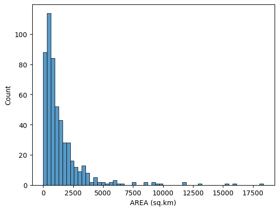

```python
# boxplot
sns.histplot(df, x = 'AREA (sq.km)')
```

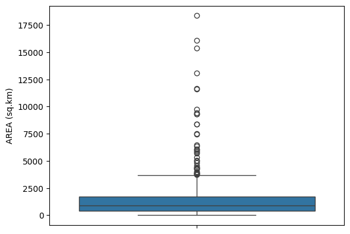

```python
sns.boxplot(df, y = 'AREA (sq.km)')
```

```python
df.columns
```

```
Index(['PROVINCE', 'DIVISION', 'DISTRICT', 'SUB DIVISION', 'AREA (sq.km)',
       'ALL SEXES (RURAL)', 'MALE (RURAL)', 'FEMALE (RURAL)',
       'TRANSGENDER (RURAL)', 'SEX RATIO (RURAL)',
       'AVG HOUSEHOLD SIZE (RURAL)', 'POPULATION 1998 (RURAL)',
       'ANNUAL GROWTH RATE (RURAL)', 'ALL SEXES (URBAN)', 'MALE (URBAN)',
       'FEMALE (URBAN)', 'TRANSGENDER (URBAN)', 'SEX RATIO (URBAN)',
       'AVG HOUSEHOLD SIZE (URBAN)', 'POPULATION 1998 (URBAN)',
       'ANNUAL GROWTH RATE (URBAN)'],
      dtype='object')
```

```python
# make a barplot by using plolty
import plotly.express as px

fig = px.bar(df, x='DIVISION', y='ALL SEXES (RURAL)')
fig.show()
```

```python
# It is very hard to plot,therefore we will use groupby function to make tabulated data output
df['DIVISION'].nunique()
```

```
28
```

```python
df.groupby(['DIVISION']).size().sort_values()
```

```
DIVISION
Badin Division                   5
MARDAN DIVISION                  7
SAHIWAL DIVISION                 7
KOHAT DIVISION                  14
MULTAN DIVISION                 14
D.G.KHAN DIVISION               14
HAZARA DIVISION                 15
BAHAWALPUR DIVISION             15
DERA ISMAIL KHAN DIVISION       15
BANNU DIVISION                  15
Shaheed Benazirabad Division    15
SARGODHA DIVISION               17
FAISALABAD DIVISION             17
LAHORE DIVISION                 17
Kalat Division                  18
Sukkur Division                 18
PESHAWAR DIVISION               18
Mirpurkhas Division             18
Naseerabad Division             19
Zhob Division                   19
GUJRANWALA DIVISION             20
Larkana Division                21
RAWALPINDI DIVISION             22
Karachi Division                30
Hyderabad Division              30
MALAKAND DIVISION               33
Makran Division                 37
Quetta Division                 38
dtype: int64
```

```python
# Calculate the mean of all sexes (rural) based on province
df.groupby('PROVINCE')['ALL SEXES (RURAL)'].mean()
```

```
PROVINCE
BALOCHISTAN     67783.465649
KPK            350603.380282
KPK/FATA        99733.760870
PUNJAB         480160.293706
SINDH          167968.182482
Name: ALL SEXES (RURAL), dtype: float64
```

```python
# Calculate the mean of all sexes (rural) based on province, division, district, & sub division
df.groupby(['PROVINCE', 'DIVISION', 'DISTRICT', 'SUB DIVISION'])['ALL SEXES (RURAL)'].mean()
```

```
PROVINCE     DIVISION         DISTRICT         SUB DIVISION
BALOCHISTAN  Kalat Division   KALAT DISTRICT   GAZG SUB-TEHSIL         5721.0
                                               JOHAN SUB-TEHSIL       10708.0
                                               KALAT TEHSIL           92298.0
                                               MANGOCHAR TEHSIL       65678.0
                                               SURAB TEHSIL          165260.0
                                                                       ...
SINDH        Sukkur Division  SUKKUR DISTRICT  NEW SUKKUR TALUKA      43652.0
                                               PANO AQIL TALUKA      336263.0
                                               ROHRI TALUKA          284840.0
                                               SALEHPAT TALUKA       102811.0
                                               SUKKUR CITY TALUKA         0.0
Name: ALL SEXES (RURAL), Length: 528, dtype: float64
```

```python
df.groupby(['PROVINCE'])['POPULATION 1998 (RURAL)'].mean()
```

```
PROVINCE
BALOCHISTAN     37944.450382
KPK            209638.816901
KPK/FATA        62657.086957
PUNJAB         350172.034965
SINDH          113796.167883
Name: POPULATION 1998 (RURAL), dtype: float64
```

```python
import pandas as pd
import plotly.graph_objs as go

# Create a new dataframe into a pandas dataframe
province = df['PROVINCE'].value_counts()

# Create a pie object
# create a Pie object
pie = go.Pie(labels=province.index, values=province.values)
# create a layout object
layout = go.Layout(title='Province distribution in Pakistan')
# create a Figure object that contains the pie chart and layout
fig = go.Figure(data=[pie], layout=layout)
# set the width and height
fig.update_layout(width=700, height=500)

# display the chart
fig.show()
```

```python
import pandas as pd
import plotly.graph_objs as go

# Create a new dataframe into a pandas dataframe
div = df['DIVISION'].value_counts()

# Create a pie object
# create a Pie object
pie = go.Pie(labels=div.index, values=div.values)
# create a layout object
layout = go.Layout(title='Total Divisions in Pakistan')
# create a Figure object that contains the pie chart and layout
fig = go.Figure(data=[pie], layout=layout)
# set the width and height
fig.update_layout(width=800, height=550)

# display the chart
fig.show()
```